# Production KPI Engine & Vision-Based Quality Inspection

### Sanitized code extract — synthetic data only

**Author:** Youssef Raziq **Context:** Extract illustrating the calculation logic and the feature-based classification approach used in a real-time production monitoring and quality control system (industrial production cell with 3 machines in series).

**Important note on data:** All data in this notebook is **synthetically generated**. No confidential production data, machine configuration, or company information is included. The purpose of this notebook is to demonstrate the calculation logic and code structure, not to reproduce the original dataset.

This notebook covers two independent contributions:

1. **Part A — KPI Engine**: OEE, MTBF and MTTR computed from timestamped machine events
2. **Part B — Vision-based quality classification**: feature-based OK/NOK part classification pipeline, illustrating the decision logic upstream of the physical rejection mechanism (PLC-driven pneumatic cylinder)

## Part A — KPI Engine: OEE, MTBF, MTTR from event logs

```python
import numpy as np
import pandas as pd
import matplotlib.pyplot as plt

rng = np.random.default_rng(seed=42)
pd.set_option("display.max_rows", 12)
```

### A.0 — Acquisition hardware

Machine events (status, cycle steps, faults) are collected by a **TEEPTRAK acquisition module (D8:C1)**, wired directly to the line's automation hardware — here alongside a Siemens Sirius safety relay, connected to the network through an RK20-ET switch and an Ubiquity E13 industrial network device. The module reads the PLC signals and timestamps each event before it is sent to the database, which feeds the KPI engine (this section), the shop-floor dashboard (Part C), the 3D twin (Part D) and Power BI (Part E).

[figure not shown]

*TEEPTRAK acquisition module (D8:C1), wired to the line's PLC/automation hardware — hardware reference photo*

### A.1 — Synthetic event log generator

Simulates a single machine's state timeline over one shift. Each event has:

- `timestamp`
- `state`: `RUNNING`, `FAULT`, `SETUP`, `WAITING_MATERIAL`
- `duration_s`
- `good_count` / `reject_count` (only relevant for `RUNNING` segments)

This mirrors the structure of the timestamped events collected from the acquisition module in the real system (machine state + production counters).

```python
def generate_shift_events(shift_minutes=450, ideal_cycle_time_s=23.0,
                           n_faults=4, n_setups=1, seed=None):
    """
    Generate a synthetic sequence of machine-state events for one shift.

    shift_minutes: total planned production time (e.g. 450 min = 7h30 shift)
    ideal_cycle_time_s: theoretical cycle time per part (seconds)
    n_faults: number of fault events injected during the shift
    n_setups: number of setup/changeover events injected during the shift
    """
    local_rng = np.random.default_rng(seed)
    total_s = shift_minutes * 60
    t = 0.0
    events = []

    # Random fault and setup start times, sorted
    fault_starts = np.sort(local_rng.uniform(0, total_s, n_faults))
    setup_starts = np.sort(local_rng.uniform(0, total_s, n_setups))

    interruptions = sorted(
        [(ts, "FAULT", local_rng.uniform(180, 900)) for ts in fault_starts] +
        [(ts, "SETUP", local_rng.uniform(300, 700)) for ts in setup_starts]
    )

    cursor = 0.0
    for start, kind, dur in interruptions:
        if start < cursor:
            continue  # skip overlapping interruption

        # RUNNING segment before this interruption
        running_dur = start - cursor
        if running_dur > 30:
            events.append(_running_segment(cursor, running_dur,
                                            ideal_cycle_time_s, local_rng))
        events.append({
            "start_s": start, "duration_s": dur, "state": kind,
            "good_count": 0, "reject_count": 0
        })
        cursor = start + dur

    # Final RUNNING segment until end of shift
    if cursor < total_s:
        events.append(_running_segment(cursor, total_s - cursor,
                                        ideal_cycle_time_s, local_rng))

    df = pd.DataFrame(events).sort_values("start_s").reset_index(drop=True)
    df["end_s"] = df["start_s"] + df["duration_s"]
    return df


def _running_segment(start_s, duration_s, ideal_cycle_time_s, rng):
    """Simulate a RUNNING segment: actual cycle time has variability
    around the theoretical value, plus a small reject rate."""
    actual_cycle_time = rng.normal(loc=ideal_cycle_time_s * 1.08,
                                    scale=ideal_cycle_time_s * 0.06)
    actual_cycle_time = max(actual_cycle_time, ideal_cycle_time_s * 0.9)
    n_parts = int(duration_s // actual_cycle_time)
    reject_rate = rng.uniform(0.01, 0.04)
    n_reject = int(round(n_parts * reject_rate))
    n_good = n_parts - n_reject
    return {
        "start_s": start_s, "duration_s": duration_s, "state": "RUNNING",
        "good_count": n_good, "reject_count": n_reject
    }

events_df = generate_shift_events(seed=7)
events_df
```

|  | start_s | duration_s | state | good_count | reject_count | end_s |
| --- | --- | --- | --- | --- | --- | --- |
| 0 | 0.000000 | 6080.594130 | RUNNING | 234 | 4 | 6080.594130 |
| 1 | 6080.594130 | 808.958481 | FAULT | 0 | 0 | 6889.552610 |
| 2 | 6889.552610 | 1214.937082 | RUNNING | 47 | 1 | 8104.489693 |
| 3 | 8104.489693 | 487.173981 | SETUP | 0 | 0 | 8591.663674 |
| 4 | 8591.663674 | 8285.913925 | RUNNING | 325 | 9 | 16877.577598 |
| 5 | 16877.577598 | 183.791019 | FAULT | 0 | 0 | 17061.368618 |
| 6 | 17061.368618 | 3882.145019 | RUNNING | 162 | 6 | 20943.513637 |
| 7 | 20943.513637 | 771.284461 | FAULT | 0 | 0 | 21714.798098 |
| 8 | 21714.798098 | 2509.974528 | RUNNING | 108 | 4 | 24224.772626 |
| 9 | 24224.772626 | 753.889989 | FAULT | 0 | 0 | 24978.662615 |
| 10 | 24978.662615 | 2021.337385 | RUNNING | 89 | 1 | 27000.000000 |

### A.2 — OEE calculation

Uses the standard three-factor decomposition, consistent with the formula validated against the real production data in the original project:

**OEE = Availability × Performance × Quality**

where, for the shift:

- `Availability = Operating Time / Planned Production Time`
- `Performance = (Ideal Cycle Time × Total Parts) / Operating Time`
- `Quality = Good Parts / Total Parts`

An equivalent single-formula form (used for the shop-floor dashboards) is:

**OEE = (Good Parts × Ideal Cycle Time) / Planned Production Time**

```python
def compute_oee(events_df, planned_production_s, ideal_cycle_time_s):
    running = events_df[events_df["state"] == "RUNNING"]

    operating_time_s = running["duration_s"].sum()
    good_parts = running["good_count"].sum()
    reject_parts = running["reject_count"].sum()
    total_parts = good_parts + reject_parts

    availability = operating_time_s / planned_production_s
    performance = (ideal_cycle_time_s * total_parts) / operating_time_s if operating_time_s > 0 else 0
    quality = good_parts / total_parts if total_parts > 0 else 0

    oee = availability * performance * quality

    # Equivalent single-formula cross-check
    oee_check = (good_parts * ideal_cycle_time_s) / planned_production_s

    return {
        "operating_time_min": operating_time_s / 60,
        "good_parts": int(good_parts),
        "reject_parts": int(reject_parts),
        "total_parts": int(total_parts),
        "availability": round(availability, 4),
        "performance": round(performance, 4),
        "quality": round(quality, 4),
        "OEE": round(oee, 4),
        "OEE_cross_check": round(oee_check, 4),
    }

SHIFT_MINUTES = 450          # 7h30 shift
IDEAL_CYCLE_TIME_S = 23.0    # theoretical cycle time

oee_result = compute_oee(events_df, SHIFT_MINUTES * 60, IDEAL_CYCLE_TIME_S)
oee_result
```

```
{'operating_time_min': np.float64(399.9150344825487),
 'good_parts': 965,
 'reject_parts': 25,
 'total_parts': 990,
 'availability': np.float64(0.8887),
 'performance': np.float64(0.949),
 'quality': np.float64(0.9747),
 'OEE': np.float64(0.822),
 'OEE_cross_check': np.float64(0.822)}
```

### A.3 — MTBF and MTTR

- **MTBF (Mean Time Between Failures)** = total operating time / number of failures
- **MTTR (Mean Time To Repair)** = total repair (fault) time / number of failures

Only `FAULT` events are counted as failures — `SETUP` and `WAITING_MATERIAL` are excluded, since they are not breakdowns.

```python
def compute_mtbf_mttr(events_df):
    running_time_s = events_df.loc[events_df["state"] == "RUNNING", "duration_s"].sum()
    faults = events_df[events_df["state"] == "FAULT"]
    n_failures = len(faults)
    total_repair_time_s = faults["duration_s"].sum()

    mtbf_min = (running_time_s / n_failures) / 60 if n_failures > 0 else np.nan
    mttr_min = (total_repair_time_s / n_failures) / 60 if n_failures > 0 else np.nan

    return {
        "n_failures": n_failures,
        "total_repair_time_min": round(total_repair_time_s / 60, 1),
        "MTBF_min": round(mtbf_min, 1),
        "MTTR_min": round(mttr_min, 1),
    }

mtbf_mttr_result = compute_mtbf_mttr(events_df)
mtbf_mttr_result
```

```
{'n_failures': 4,
 'total_repair_time_min': np.float64(42.0),
 'MTBF_min': np.float64(100.0),
 'MTTR_min': np.float64(10.5)}
```

### A.4 — Visualization: shift timeline and KPI summary

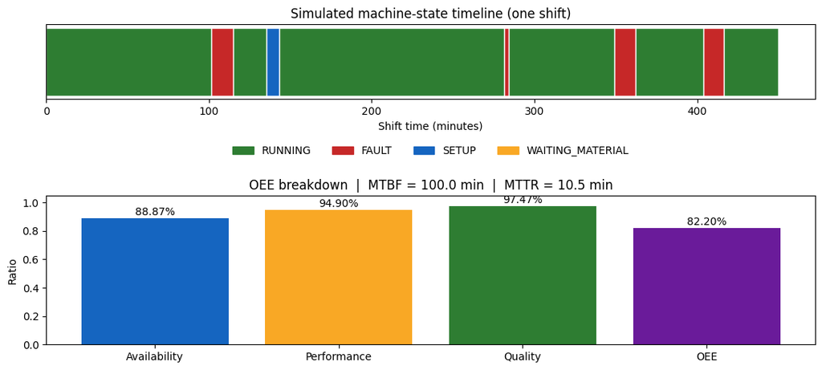

```python
fig, axes = plt.subplots(2, 1, figsize=(11, 5), gridspec_kw={"height_ratios": [1, 2]})

color_map = {"RUNNING": "#2E7D32", "FAULT": "#C62828",
             "SETUP": "#1565C0", "WAITING_MATERIAL": "#F9A825"}

ax = axes[0]
for _, row in events_df.iterrows():
    ax.barh(0, row["duration_s"] / 60, left=row["start_s"] / 60,
            color=color_map[row["state"]], edgecolor="white", height=0.6)
ax.set_yticks([])
ax.set_xlabel("Shift time (minutes)")
ax.set_title("Simulated machine-state timeline (one shift)")
handles = [plt.Rectangle((0, 0), 1, 1, color=c) for c in color_map.values()]
ax.legend(handles, color_map.keys(), loc="upper center",
          bbox_to_anchor=(0.5, -0.5), ncol=4, frameon=False)

ax2 = axes[1]
labels = ["Availability", "Performance", "Quality", "OEE"]
values = [oee_result["availability"], oee_result["performance"],
          oee_result["quality"], oee_result["OEE"]]
bars = ax2.bar(labels, values, color=["#1565C0", "#F9A825", "#2E7D32", "#6A1B9A"])
ax2.set_ylim(0, 1.05)
ax2.set_ylabel("Ratio")
mtbf_val = mtbf_mttr_result["MTBF_min"]
mttr_val = mtbf_mttr_result["MTTR_min"]
ax2.set_title(f"OEE breakdown  |  MTBF = {mtbf_val} min  |  MTTR = {mttr_val} min")
for b, v in zip(bars, values):
    ax2.text(b.get_x() + b.get_width()/2, v + 0.02, f"{v:.2%}", ha="center")

plt.tight_layout()
plt.show()
```

## Part B — Vision-based quality classification (OK / NOK)

### Hardware and inspection task

The physical inspection point uses a **Keyence IV4-G500CA smart vision sensor**, mounted above the line next to the pneumatic ejector. It is positioned to check the **yellow screw injection points** on the part: each injection point must be present, correctly shaped and correctly positioned. If a screw injection point is missing, malformed, or mislocated, the part is classified `NOK`.

**Decision loop:**

```
Part reaches inspection point
        │
        ▼
Keyence IV4-G500CA vision sensor
inspects the yellow injection points
        │
        ▼
   Decision: OK / NOK
        │
   ┌────┴────┐
   ▼         ▼
  OK        NOK
   │         │
part continues   PLC triggers the pneumatic
on the line       cylinder → part pushed to
                  a separate reject bin
        │
        ▼
Event logged (decision, confidence, timestamp)
→ acquisition module → database
```

**Approach used here:** a feature-based classifier trained on engineered features that summarize what the vision sensor's tool actually measures for this application — color match, blob shape/size and positional deviation of the injection points — rather than raw pixels. This keeps the pipeline lightweight, explainable, and easy to validate against manually labelled parts, matching the validation approach used for the real system.

**Honest note on ownership:** the Keyence IV4 series is a vendor smart camera with a built-in AI/blob-detection tool, configured and trained in-application by showing OK/NOK reference samples — this is not a from-scratch deep-learning model coded in Python. The code below reproduces the *decision logic and evaluation methodology* applied to that sensor's output (feature-based classification, precision/recall analysis, PLC integration), which is the part I implemented myself; it is not a reimplementation of the sensor's internal algorithm.

[figure not shown]

*Keyence IV4-G500CA vision sensor mounted on the line, next to the pneumatic ejector*

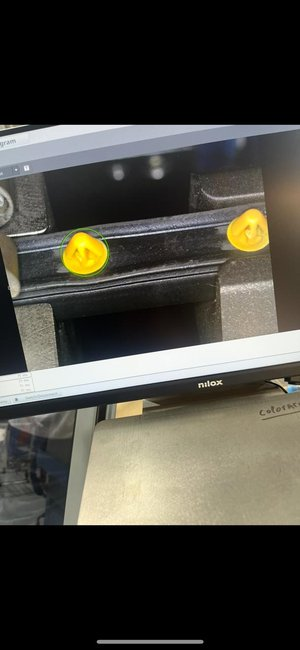

*Detection tool output: yellow screw injection points identified and circled by the vision sensor's tool*

```python
from sklearn.model_selection import train_test_split
from sklearn.ensemble import RandomForestClassifier
from sklearn.metrics import (accuracy_score, precision_score, recall_score,
                              f1_score, confusion_matrix, ConfusionMatrixDisplay)

def generate_synthetic_parts(n_ok=800, n_nok=120, seed=None):
    """
    Synthetic feature vectors for inspected parts, engineered to reflect
    what the vision sensor's tool measures for THIS application: detecting
    the yellow screw injection points on the part.

      - color_match_score : 0-1 similarity to reference yellow (1 = perfect match)
      - blob_area_px       : detected blob area in pixels (expected ~ reference size)
      - circularity        : 0-1 shape regularity of the injection point (1 = perfect circle)
      - position_offset_mm : deviation from the expected injection-point location
    """
    local_rng = np.random.default_rng(seed)

    ok = pd.DataFrame({
        "color_match_score":  local_rng.normal(0.93, 0.03, n_ok).clip(0, 1),
        "blob_area_px":       local_rng.normal(420, 25, n_ok).clip(0, None),
        "circularity":        local_rng.normal(0.90, 0.04, n_ok).clip(0, 1),
        "position_offset_mm": local_rng.normal(0.15, 0.08, n_ok).clip(0, None),
        "label": "OK",
    })

    nok = pd.DataFrame({
        "color_match_score":  local_rng.normal(0.55, 0.20, n_nok).clip(0, 1),
        "blob_area_px":       local_rng.normal(260, 110, n_nok).clip(0, None),
        "circularity":        local_rng.normal(0.55, 0.20, n_nok).clip(0, 1),
        "position_offset_mm": local_rng.normal(0.9, 0.5, n_nok).clip(0, None),
        "label": "NOK",
    })

    return pd.concat([ok, nok], ignore_index=True).sample(frac=1, random_state=seed).reset_index(drop=True)

parts_df = generate_synthetic_parts(seed=11)
parts_df.groupby("label").mean(numeric_only=True)
```

| label | color_match_score | blob_area_px | circularity | position_offset_mm |
| --- | --- | --- | --- | --- |
| NOK | 0.546409 | 251.947787 | 0.542757 | 0.924999 |
| OK | 0.930098 | 419.923595 | 0.900940 | 0.153546 |

```python
feature_cols = ["color_match_score", "blob_area_px",
                "circularity", "position_offset_mm"]

X = parts_df[feature_cols]
y = parts_df["label"]

X_train, X_test, y_train, y_test = train_test_split(
    X, y, test_size=0.25, stratify=y, random_state=11
)

clf = RandomForestClassifier(n_estimators=200, max_depth=5, random_state=11)
clf.fit(X_train, y_train)

y_pred = clf.predict(X_test)

metrics = {
    "accuracy":  round(accuracy_score(y_test, y_pred), 4),
    "precision_NOK": round(precision_score(y_test, y_pred, pos_label="NOK"), 4),
    "recall_NOK":    round(recall_score(y_test, y_pred, pos_label="NOK"), 4),
    "f1_NOK":        round(f1_score(y_test, y_pred, pos_label="NOK"), 4),
}
metrics
```

```
{'accuracy': 0.9957,
 'precision_NOK': 1.0,
 'recall_NOK': 0.9667,
 'f1_NOK': 0.9831}
```

### B.1 — Confusion matrix & feature importance

For a quality-gate application, **recall on NOK** (catching real defects) is usually prioritized over overall accuracy, since a missed defect (false acceptance) is more costly than an over-rejected good part (false rejection).

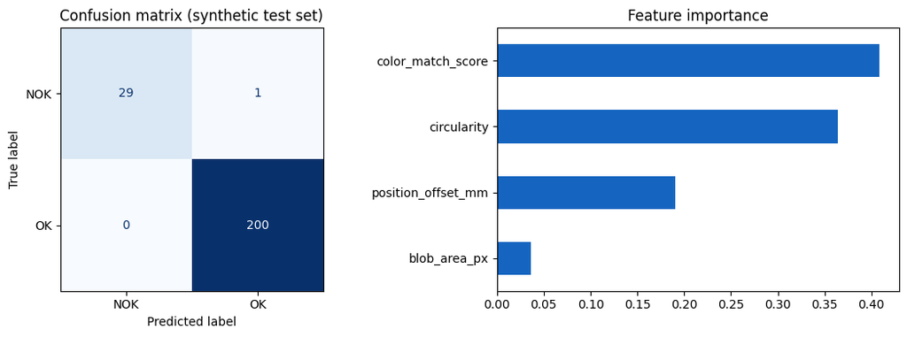

```python
fig, axes = plt.subplots(1, 2, figsize=(11, 4))

ConfusionMatrixDisplay.from_predictions(
    y_test, y_pred, ax=axes[0], colorbar=False, cmap="Blues"
)
axes[0].set_title("Confusion matrix (synthetic test set)")

importances = pd.Series(clf.feature_importances_, index=feature_cols).sort_values()
importances.plot.barh(ax=axes[1], color="#1565C0")
axes[1].set_title("Feature importance")

plt.tight_layout()
plt.show()
```

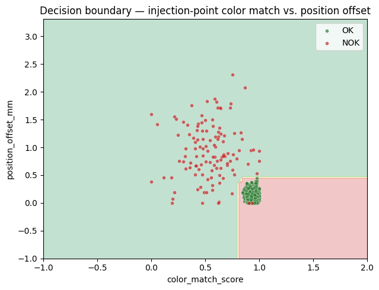

```python
from sklearn.inspection import DecisionBoundaryDisplay

viz_features = ["color_match_score", "position_offset_mm"]
X_viz = parts_df[viz_features]
y_viz = parts_df["label"]

clf_viz = RandomForestClassifier(n_estimators=200, max_depth=5, random_state=11)
clf_viz.fit(X_viz, y_viz)

fig, ax = plt.subplots(figsize=(6.5, 5))

DecisionBoundaryDisplay.from_estimator(
    clf_viz, X_viz, response_method="predict", alpha=0.25,
    cmap="RdYlGn_r", ax=ax, xlabel=viz_features[0], ylabel=viz_features[1]
)

for label, color in [("OK", "#2E7D32"), ("NOK", "#C62828")]:
    subset = parts_df[parts_df["label"] == label]
    ax.scatter(subset[viz_features[0]], subset[viz_features[1]],
               s=18, alpha=0.7, label=label, color=color, edgecolor="white", linewidth=0.3)

ax.set_title("Decision boundary — injection-point color match vs. position offset")
ax.legend()
plt.tight_layout()
plt.show()
```

### B.3 — Simulated inline decision (PLC and pneumatic cylinder integration)

Illustrates how a single part's classification result drives the downstream physical action: if `NOK`, the PLC fires the pneumatic cylinder to push the part into the reject bin; if `OK`, the part continues on the line. The decision, confidence and PLC command are logged as a timestamped event for the acquisition module.

```python
import datetime as dt

def inspect_part(feature_vector, model, part_id):
    """Simulate one inline inspection decision and the resulting PLC action."""
    proba = model.predict_proba([feature_vector])[0]
    classes = model.classes_
    decision = classes[np.argmax(proba)]
    confidence = float(np.max(proba))

    if decision == "NOK":
        plc_command = "REJECT"
        physical_action = "Pneumatic cylinder fires -> part pushed to reject bin"
    else:
        plc_command = "PASS"
        physical_action = "Part continues on the line"

    event = {
        "timestamp": dt.datetime.now().isoformat(timespec="seconds"),
        "part_id": part_id,
        "decision": decision,
        "confidence": round(confidence, 3),
        "plc_command": plc_command,
        "physical_action": physical_action,
    }
    return event

# Example: inspect 5 random parts from the test set
sample = X_test.sample(5, random_state=1)
for i, (_, row) in enumerate(sample.iterrows()):
    print(inspect_part(row.values, clf, part_id=f"PN-{1000+i}"))
```

```
{'timestamp': '2026-07-19T15:50:25', 'part_id': 'PN-1000', 'decision': 'OK', 'confidence': 1.0, 'plc_command': 'PASS', 'physical_action': 'Part continues on the line'}
{'timestamp': '2026-07-19T15:50:25', 'part_id': 'PN-1001', 'decision': 'OK', 'confidence': 1.0, 'plc_command': 'PASS', 'physical_action': 'Part continues on the line'}
{'timestamp': '2026-07-19T15:50:25', 'part_id': 'PN-1002', 'decision': 'NOK', 'confidence': 1.0, 'plc_command': 'REJECT', 'physical_action': 'Pneumatic cylinder fires -> part pushed to reject bin'}
{'timestamp': '2026-07-19T15:50:25', 'part_id': 'PN-1003', 'decision': 'OK', 'confidence': 0.995, 'plc_command': 'PASS', 'physical_action': 'Part continues on the line'}
{'timestamp': '2026-07-19T15:50:25', 'part_id': 'PN-1004', 'decision': 'OK', 'confidence': 1.0, 'plc_command': 'PASS', 'physical_action': 'Part continues on the line'}
```

## Summary — Parts A & B

[output not shown]

In the deployed system, `events_df` is populated from the acquisition module's event stream (state, counters, timestamps) instead of `generate_shift_events()`, and `parts_df` is replaced by the vision sensor's actual measured features instead of `generate_synthetic_parts()`. The calculation, evaluation and PLC-integration logic shown here is otherwise unchanged from the real implementation.

## Part C — Real-time shop-floor dashboard

Two screens are mounted directly in the workshop, above the line, displaying live KPIs for each machine. Each screen refreshes automatically from the acquisition system and uses a **color-coding rule** so operators can read the line's status at a glance without reading numbers:

- **Red bar** — current OEE below the shift's OEE objective (here: 75.00%)
- **Green indicator** — metric at or above objective
- **Orange/amber** — approaching the scrap-rate objective, used as a warning zone

This is the same acquisition pipeline described in Part A (TEEPTRAK events → database) feeding a browser-based dashboard, refreshed on a short polling interval so the displayed state stays close to real time.

[figure not shown]

*Real-time shop-floor dashboards deployed above the production line (OEE and scrap-rate objectives, color-coded status)*

### C.1 — Color-coding logic

This is the actual decision logic behind the red/green/orange indicators shown above: comparing each live KPI against its objective and a warning margin. It is a small piece of code, but it is the part I wrote myself — the acquisition and the rendering are handled upstream/downstream of it.

```python
def status_color(value, objective, higher_is_better=True, warning_margin=0.05):
    """
    Determine the dashboard indicator color for a KPI value against its
    objective, matching the rule used on the shop-floor screens.

    higher_is_better=True  -> e.g. OEE (objective is a minimum to reach)
    higher_is_better=False -> e.g. scrap rate (objective is a maximum not to exceed)
    """
    if higher_is_better:
        if value >= objective:
            return "GREEN"
        elif value >= objective * (1 - warning_margin):
            return "ORANGE"
        else:
            return "RED"
    else:
        if value <= objective:
            return "GREEN"
        elif value <= objective * (1 + warning_margin):
            return "ORANGE"
        else:
            return "RED"

# Example matching the screens above
examples = [
    {"machine": "Clipping 2", "oee": 0.58, "oee_objective": 0.75},
    {"machine": "Clipping 1", "oee": 0.76, "oee_objective": 0.75},
]
for ex in examples:
    color = status_color(ex["oee"], ex["oee_objective"], higher_is_better=True)
    machine_name = ex["machine"]
    oee_val = ex["oee"]
    oee_obj = ex["oee_objective"]
    print(f"{machine_name}: OEE={oee_val:.0%} vs objective {oee_obj:.0%} -> {color}")
```

```
Clipping 2: OEE=58% vs objective 75% -> RED
Clipping 1: OEE=76% vs objective 75% -> GREEN
```

## Part D — 3D digital-twin visualization (Siemens Tecnomatix Plant Simulation)

The 3D live-state scene is built in **Siemens Tecnomatix Plant Simulation**, representing the F2X line layout (machines, buffers, material flow).

**Data path:** Tecnomatix does not read the PLC directly. It connects through an **OPC UA server built on top of the acquisition database** — the same database fed by the TEEPTRAK module described in Part A.0:

```
PLC (automate)
      │
      ▼
TEEPTRAK acquisition module
      │
      ▼
Production database
      │
      ▼
OPC UA server (exposes machine states, counters, stock levels
               as OPC UA nodes, read from the database)
      │
      ▼
Tecnomatix Plant Simulation (subscribes to the OPC UA nodes,
                              updates the 3D scene)
```

This means Tecnomatix, the shop-floor dashboard (Part C) and Power BI (Part E) are three independent consumers of the same acquisition layer — they read the same underlying data through different connectors (OPC UA for Tecnomatix, direct database/API for the dashboard and Power BI).

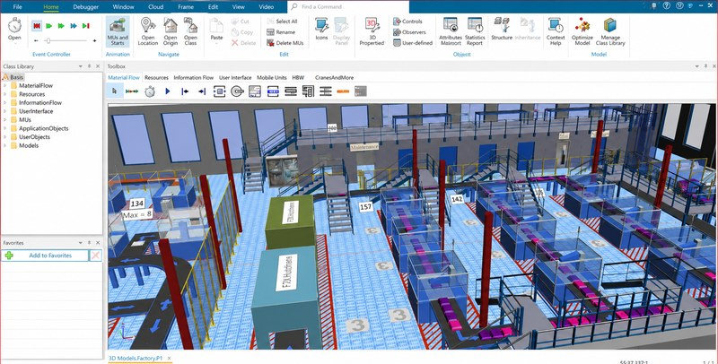

*Siemens Tecnomatix Plant Simulation — F2X line 3D model*

### D.1 — OPC UA node mapping

This is the data contract exposed by the OPC UA server (built on top of the production database) and consumed by the Tecnomatix model: each machine and buffer is mapped to a set of OPC UA nodes, sourced from the same TEEPTRAK-fed database used by the KPI engine (Part A) and the shop-floor dashboard (Part C).

```python
import json

def build_opcua_node_map(events_df, oee_result, mtbf_mttr_result):
    """
    Build the OPC UA node mapping exposed by the OPC UA server sitting on
    top of the production database (itself fed by the TEEPTRAK acquisition
    module). Tecnomatix Plant Simulation subscribes to these nodes to keep
    the 3D scene synchronized with the physical line. Node paths follow
    the pattern: ns=2;s=<Line>.<Asset>.<Variable>
    """
    last_row = events_df.iloc[-1]
    nodes = {
        "ns=2;s=F2X.Line.Status": last_row["state"],
        "ns=2;s=F2X.Line.Timestamp": pd.Timestamp.now().isoformat(timespec="seconds"),
        "ns=2;s=F2X.KPI.OEE": oee_result["OEE"],
        "ns=2;s=F2X.KPI.GoodParts": oee_result["good_parts"],
        "ns=2;s=F2X.KPI.RejectParts": oee_result["reject_parts"],
        "ns=2;s=F2X.KPI.MTBF_min": mtbf_mttr_result["MTBF_min"],
        "ns=2;s=F2X.KPI.MTTR_min": mtbf_mttr_result["MTTR_min"],
    }
    return nodes

opcua_nodes = build_opcua_node_map(events_df, oee_result, mtbf_mttr_result)
print(json.dumps(opcua_nodes, indent=2))
```

```
{
  "ns=2;s=F2X.Line.Status": "RUNNING",
  "ns=2;s=F2X.Line.Timestamp": "2026-07-19T15:50:25",
  "ns=2;s=F2X.KPI.OEE": 0.822,
  "ns=2;s=F2X.KPI.GoodParts": 965,
  "ns=2;s=F2X.KPI.RejectParts": 25,
  "ns=2;s=F2X.KPI.MTBF_min": 100.0,
  "ns=2;s=F2X.KPI.MTTR_min": 10.5
}
```

## Part E — Power BI: analysis and improvement-action recommendations

Power BI consumes the same production events (via the acquisition system's API) to build trend reports and to support decisions on where to focus improvement actions. Two things are shown here:

1. **DAX measures** (illustrative, not executed in this Python notebook — DAX is Power BI's native formula language) representative of the measures used in the real dashboards
2. **A small Python rule-engine** reproducing the improvement-action logic: given a KPI trend, propose a concrete action — this part *is* runnable Python and is the piece I implemented myself

### E.0 — Real Power BI report (from the PFE defense)

Downtime analysis report built from the acquired events: total downtimes, breakdown by reason (material feed, planned stops, machine blocking, scrap, technical failure), daily percentages and a Pareto chart of downtime causes. This report is the direct downstream consumer of the same timestamped events used in Part A.

[figure not shown]

*Power BI report — production downtime analysis (from the PFE defense presentation)*

### E.1 — Representative DAX measures (Power BI)

```
OEE % :=
DIVIDE ( [Good Parts], [Total Parts] ) *
DIVIDE ( [Operating Time], [Planned Production Time] ) *
DIVIDE ( [Ideal Cycle Time] * [Total Parts], [Operating Time] )

Scrap Rate % :=
DIVIDE ( [Reject Parts], [Total Parts] )

MTBF (min) :=
DIVIDE ( [Operating Time (min)], [Failure Count] )

MTTR (min) :=
DIVIDE ( [Total Repair Time (min)], [Failure Count] )
```

### E.2 — Improvement-action rule engine

A small rule-based function that takes the latest KPI snapshot and proposes concrete improvement actions — the kind of logic behind the "actions d'amélioration" surfaced from the Power BI analysis layer.

```python
def recommend_actions(kpi_snapshot, targets):
    """
    kpi_snapshot: dict with current OEE, scrap_rate, mtbf_min, mttr_min
    targets: dict with the corresponding objectives
    Returns a list of recommended improvement actions, most urgent first.
    """
    actions = []

    if kpi_snapshot["oee"] < targets["oee"]:
        gap = targets["oee"] - kpi_snapshot["oee"]
        actions.append({
            "priority": "HIGH" if gap > 0.10 else "MEDIUM",
            "action": "Investigate availability/performance losses on the "
                       "bottleneck machine (OEE below objective)",
            "gap": round(gap, 3),
        })

    if kpi_snapshot["scrap_rate"] > targets["scrap_rate"]:
        actions.append({
            "priority": "HIGH",
            "action": "Review process parameters and inspection thresholds "
                       "(scrap rate above objective)",
            "gap": round(kpi_snapshot["scrap_rate"] - targets["scrap_rate"], 4),
        })

    if kpi_snapshot["mttr_min"] > targets["mttr_min"]:
        actions.append({
            "priority": "MEDIUM",
            "action": "Review breakdown response procedure and spare-parts "
                       "availability (MTTR above objective)",
            "gap": round(kpi_snapshot["mttr_min"] - targets["mttr_min"], 1),
        })

    if not actions:
        actions.append({"priority": "NONE",
                         "action": "All KPIs within objective — no action required",
                         "gap": 0})

    return sorted(actions, key=lambda a: {"HIGH": 0, "MEDIUM": 1, "NONE": 2}[a["priority"]])

kpi_snapshot = {
    "oee": oee_result["OEE"],
    "scrap_rate": oee_result["reject_parts"] / oee_result["total_parts"],
    "mttr_min": mtbf_mttr_result["MTTR_min"],
}
targets = {"oee": 0.75, "scrap_rate": 0.0179, "mttr_min": 20.0}

for a in recommend_actions(kpi_snapshot, targets):
    print(a)
```

```
{'priority': 'HIGH', 'action': 'Review process parameters and inspection thresholds (scrap rate above objective)', 'gap': 0.0074}
```

## Final summary

| Block | Nature | What it demonstrates |
| --- | --- | --- |
| Part A — KPI engine | Own code | OEE / MTBF / MTTR from timestamped events |
| Part B — Vision classification | Own code + real hardware | OK/NOK decision pipeline, PLC/cylinder integration |
| Part C — Shop-floor dashboard | Own code + real deployment photo | Color-coded live status, deployed on two screens in the workshop |
| Part D — 3D twin (Tecnomatix) | Own model + real-time OPC UA link | 3D scene synchronized with live machine states via OPC UA |
| Part E — Power BI | Own code + illustrative DAX | Trend analysis and rule-based improvement-action recommendations |